# Tugas 1 MPDW

Alfiah Ayu Hapsari

2023-08-31

## Library / Packages

```r
library("forecast")
```

```r
library("graphics")
library("TTR")
library("TSA")
```

## Impor Data

```r
library(rio)
data <- import("https://raw.githubusercontent.com/alfiahayu/mpdw/main/Data/data%20mpdw.csv")
```

## Eksplorasi Data

Melihat data menggunakan fungsi `View()`, struktur data menggunakan fungsi `str()`, dan dimensi data menggunakan fungsi `dim()`.

```r
View(data)
str(data)
```

```
## 'data.frame':    139 obs. of  2 variables:
##  $ Periode: IDate, format: "2021-01-03" "2021-01-10" ...
##  $ Harga  : int  14500 14500 14500 14500 14500 14550 14500 14500 14550 14650 ...
```

```r
dim(data)
```

```
## [1] 139   2
```

Mengubah data agar terbaca sebagai data deret waktu dengan fungsi `ts()` .

```r
data.ts <- ts(data$Harga)
```

Menampilkan ringkasan data

```r
summary(data.ts)
```

```
##    Min. 1st Qu.  Median    Mean 3rd Qu.    Max.
##   14500   16025   19200   18654   19550   24800
```

Membuat plot data deret waktu

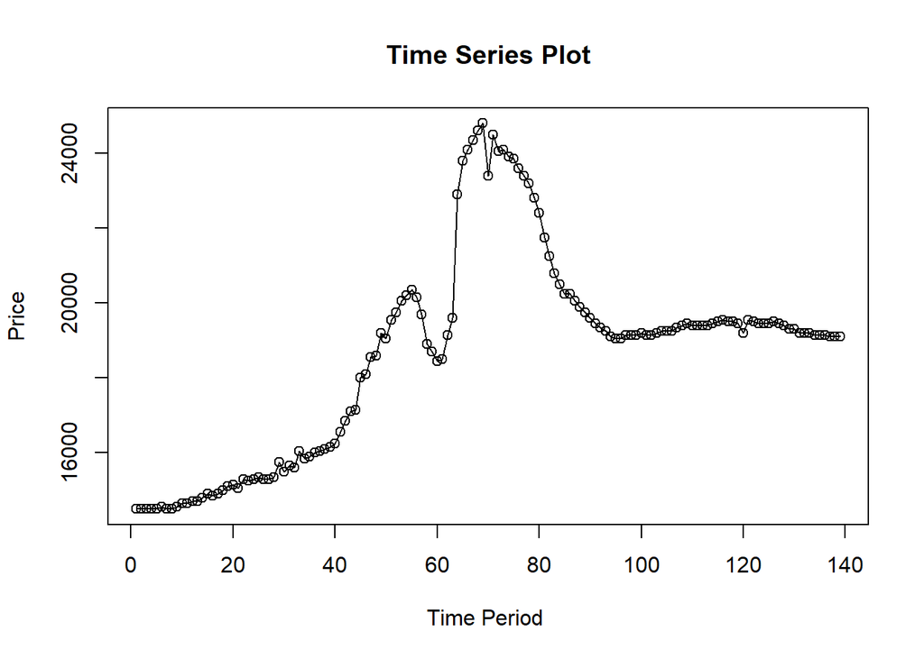

```r
ts.plot(data.ts, xlab="Time Period ", ylab="Price",
        main = "Time Series Plot")
points(data.ts)
```

### Pembagian Data

Pembagian data latih dan data uji dilakukan dengan perbandingan 80% data latih dan 20% data uji.

```r
#membagi data latih dan data uji
training <- data[1:112,]
testing <- data[113:139,]
train.ts <- ts(training$Harga)
test.ts <- ts(testing$Harga)
```

### Eksplorasi Data

Eksplorasi data dilakukan pada keseluruhan data, data latih serta data uji menggunakan plot data deret waktu.

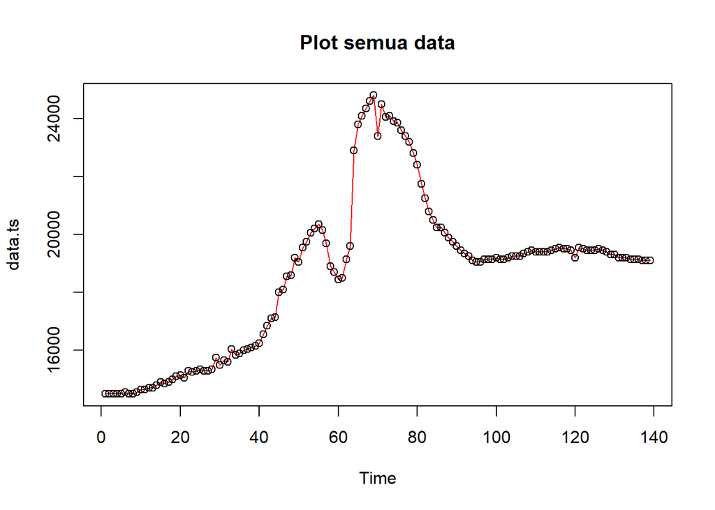

```r
#eksplorasi keseluruhan data
plot(data.ts, col="red",main="Plot semua data")
points(data.ts)
```

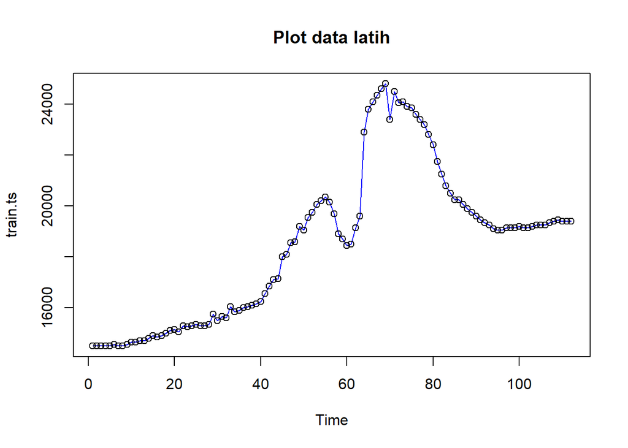

```r
#eksplorasi data latih
plot(train.ts, col="blue",main="Plot data latih")
points(train.ts)
```

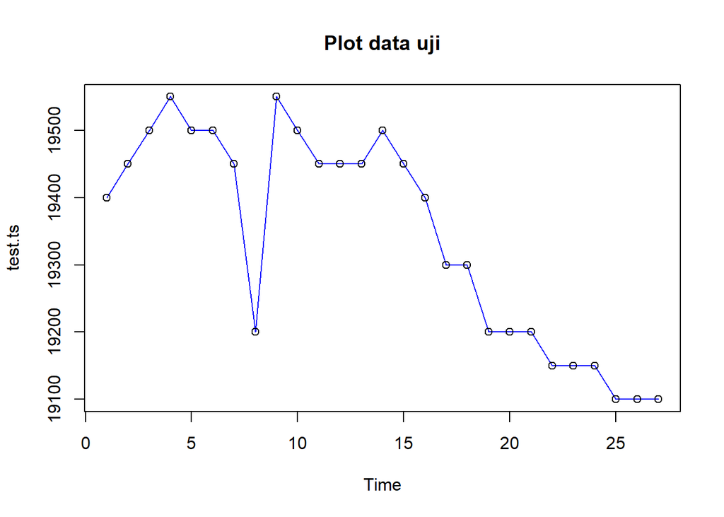

```r
#eksplorasi data uji
plot(test.ts, col="blue",main="Plot data uji")
points(test.ts)
```

Eksplorasi data juga dapat dilakukan menggunakan package `ggplot2` dengan terlebih dahulu memanggil library *package* `ggplot2`.

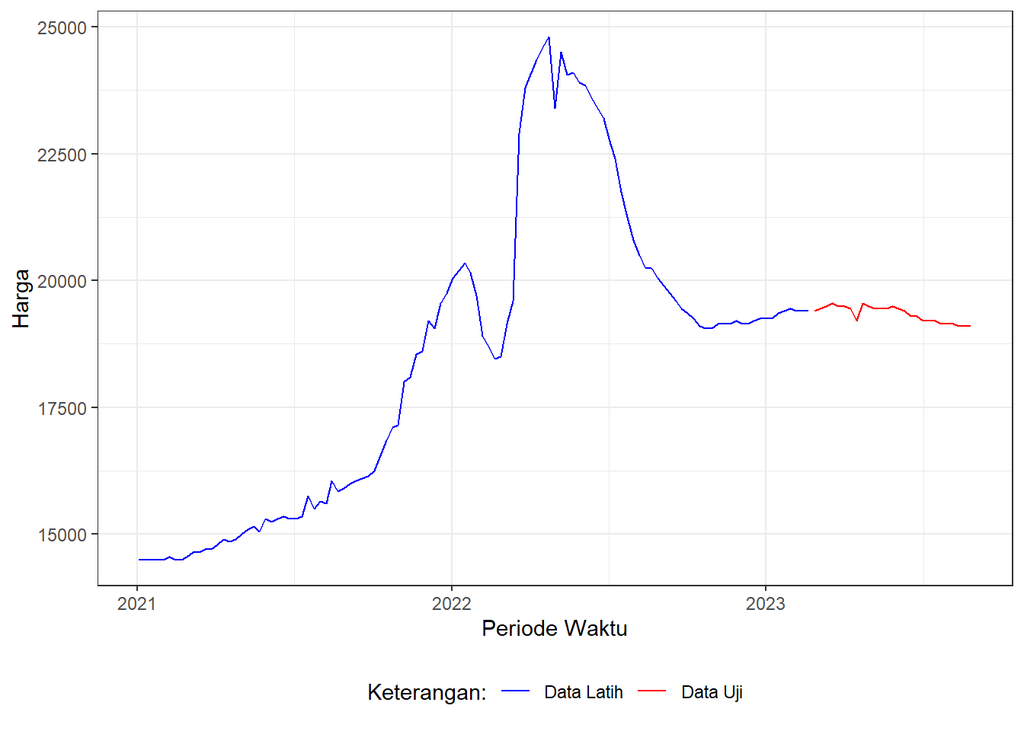

```r
#Eksplorasi dengan GGPLOT
library(ggplot2)
ggplot() +
  geom_line(data = training, aes(x = Periode, y = Harga, col = "Data Latih")) +
  geom_line(data = testing, aes(x = Periode, y = Harga, col = "Data Uji")) +
  labs(x = "Periode Waktu", y = "Harga", color = "Legend") +
  scale_colour_manual(name="Keterangan:", breaks = c("Data Latih", "Data Uji"),
                      values = c("blue", "red")) +
  theme_bw() + theme(legend.position = "bottom",
                     plot.caption = element_text(hjust=0.5, size=12))
```

### Double Moving Average (DMA)

Karena pola data cenderung tren maka metode yang lebih baik digunakan adalah metode Double Moving Average (DMA). Metode pemulusan Double Moving Average (DMA) pada dasarnya mirip dengan SMA. Namun demikian, metode ini lebih cocok digunakan untuk pola data trend. Proses pemulusan dengan rata rata dalam metode ini dilakukan sebanyak 2 kali. Pemulusan menggunakan metode DMA dilakukan dengan fungsi `SMA()`. Dalam hal ini akan dilakukan pemulusan dengan parameter `m=2`.

```r
data.sma<-SMA(train.ts, n=2)
data.sma
```

```
## Time Series:
## Start = 1
## End = 112
## Frequency = 1
##   [1]    NA 14500 14500 14500 14500 14525 14525 14500 14525 14600 14650 14675
##  [13] 14700 14750 14850 14875 14875 14950 15050 15125 15100 15175 15275 15275
##  [25] 15325 15325 15300 15325 15550 15625 15575 15625 15825 15950 15875 15950
##  [37] 16025 16075 16125 16200 16400 16700 16975 17125 17575 18050 18325 18575
##  [49] 18900 19125 19300 19650 19900 20125 20275 20250 19925 19300 18800 18575
##  [61] 18475 18825 19375 21250 23350 23950 24225 24475 24700 24100 23950 24275
##  [73] 24075 24000 23875 23725 23500 23300 23000 22600 22075 21500 21025 20650
##  [85] 20375 20250 20150 19975 19825 19675 19525 19400 19300 19175 19075 19050
##  [97] 19100 19150 19150 19175 19175 19150 19175 19225 19250 19250 19300 19375
## [109] 19425 19425 19400 19400
```

```r
dma <- SMA(data.sma, n = 2)
At <- 2*data.sma - dma
Bt <- 2/(2-1)*(data.sma - dma)
data.dma<- At+Bt
data.ramal2<- c(NA, data.dma)

t = 1:27
f = c()

for (i in t) {
  f[i] = At[length(At)] + Bt[length(Bt)]*(i)
}

data.gab2 <- cbind(aktual = c(train.ts,rep(NA,27)), pemulusan1 = c(data.sma,rep(NA,27)),pemulusan2 = c(data.dma, rep(NA,27)),At = c(At, rep(NA,27)), Bt = c(Bt,rep(NA,27)),ramalan = c(data.ramal2, f[-1]))
data.gab2
```

```
##        aktual pemulusan1 pemulusan2      At   Bt ramalan
##   [1,]  14500         NA         NA      NA   NA      NA
##   [2,]  14500      14500         NA      NA   NA      NA
##   [3,]  14500      14500    14500.0 14500.0    0      NA
##   [4,]  14500      14500    14500.0 14500.0    0 14500.0
##   [5,]  14500      14500    14500.0 14500.0    0 14500.0
##   [6,]  14550      14525    14562.5 14537.5   25 14500.0
##   [7,]  14500      14525    14525.0 14525.0    0 14562.5
##   [8,]  14500      14500    14462.5 14487.5  -25 14525.0
##   [9,]  14550      14525    14562.5 14537.5   25 14462.5
##  [10,]  14650      14600    14712.5 14637.5   75 14562.5
##  [11,]  14650      14650    14725.0 14675.0   50 14712.5
##  [12,]  14700      14675    14712.5 14687.5   25 14725.0
##  [13,]  14700      14700    14737.5 14712.5   25 14712.5
##  [14,]  14800      14750    14825.0 14775.0   50 14737.5
```

[output cut: 125 more lines]

Hasil pemulusan menggunakan metode DMA divisualisasikan sebagai berikut

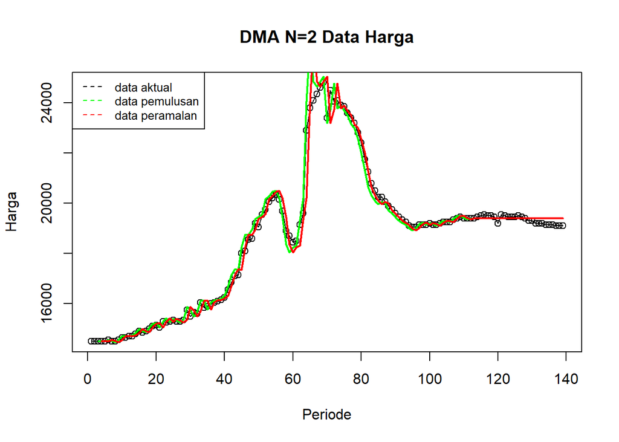

```r
ts.plot(data.ts, xlab="Periode", ylab="Harga", main= "DMA N=2 Data Harga")
points(data.ts)
lines(data.gab2[,3],col="green",lwd=2)
lines(data.gab2[,6],col="red",lwd=2)
legend("topleft",c("data aktual","data pemulusan","data peramalan"), lty=8, col=c("black","green","red"), cex=0.8)
```

Selanjutnya perhitungan akurasi dilakukan baik pada data latih maupun data uji. Perhitungan akurasi dilakukan dengan ukuran akurasi SSE, MSE dan MAPE.

```r
#Menghitung nilai keakuratan data latih
error_train.dma = train.ts-data.ramal2[1:length(train.ts)]
SSE_train.dma = sum(error_train.dma[8:length(train.ts)]^2)
MSE_train.dma = mean(error_train.dma[8:length(train.ts)]^2)
MAPE_train.dma = mean(abs((error_train.dma[8:length(train.ts)]/train.ts[8:length(train.ts)])*100))

akurasi_train.dma <- matrix(c(SSE_train.dma, MSE_train.dma, MAPE_train.dma))
row.names(akurasi_train.dma)<- c("SSE", "MSE", "MAPE")
colnames(akurasi_train.dma) <- c("Akurasi m = 2")
akurasi_train.dma
```

```
##      Akurasi m = 2
## SSE   2.222641e+07
## MSE   2.116801e+05
## MAPE  1.111274e+00
```

Nilai MAPE yang dihasilkan pada metode DMA yaitu sebesar 1.1%. Hal ini menunjukkan bahwa perhitungan akurasi pada data latih dikategorikan sangat baik karena kurang dari 10%. Selanjutnya, perhitungan nilai akurasi dilakukan pada data uji.

```r
#Menghitung nilai keakuratan data uji
error_test.dma = test.ts-data.gab2[113:139,6]
SSE_test.dma = sum(error_test.dma^2)
MSE_test.dma = mean(error_test.dma^2)
MAPE_test.dma = mean(abs((error_test.dma/test.ts*100)))

akurasi_test.dma <- matrix(c(SSE_test.dma, MSE_test.dma, MAPE_test.dma))
row.names(akurasi_test.dma)<- c("SSE", "MSE", "MAPE")
colnames(akurasi_test.dma) <- c("Akurasi m = 2")
akurasi_test.dma
```

```
##      Akurasi m = 2
## SSE   7.475000e+05
## MSE   2.768519e+04
## MAPE  7.212027e-01
```

Perhitungan akurasi menggunakan data latih menghasilkan nilai MAPE yang kurang dari 10% sehingga nilai akurasi ini dapat dikategorikan sebagai sangat baik.

## Double Exponential Smoothing (DES)

Metode pemulusan yang digunakan selanjutnya yaitu metode pemulusan Double Exponential Smoothing (DES). Metode pemulusan *Double Exponential Smoothing* (DES) digunakan untuk data yang memiliki pola tren. Metode DES adalah metode semacam SES, hanya saja dilakukan dua kali, yaitu pertama untuk tahapan ‘level’ dan kedua untuk tahapan ‘tren’. Pemulusan menggunakan metode ini akan menghasilkan peramalan tidak konstan untuk periode berikutnya.

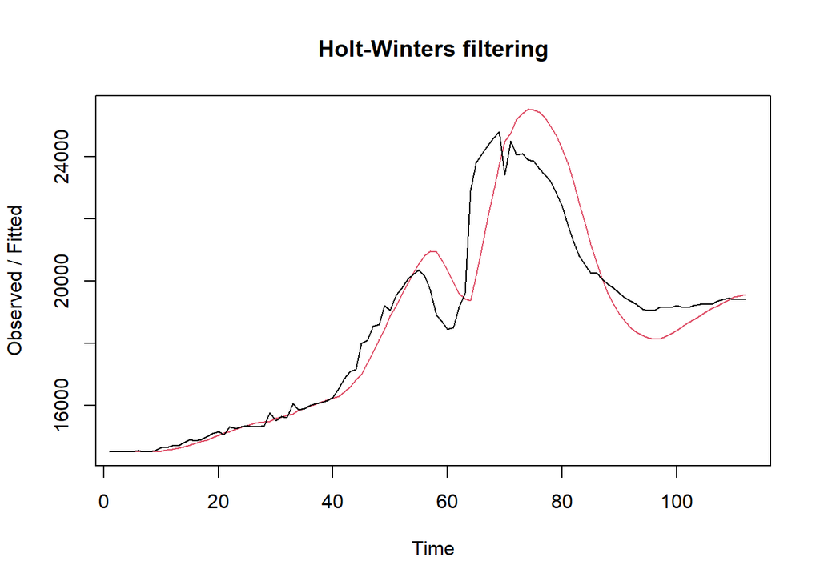

```r
#Lamda=0.2 dan gamma=0.2
des.1<- HoltWinters(train.ts, gamma = FALSE, beta = 0.2, alpha = 0.2)
plot(des.1)
```

```r
#ramalan
ramalandes1<- forecast(des.1, h=27)
ramalandes1
```

```
##     Point Forecast    Lo 80    Hi 80    Lo 95    Hi 95
## 113       19595.67 18285.34 20906.00 17591.69 21599.65
## 114       19654.78 18307.24 21002.32 17593.89 21715.67
## 115       19713.89 18317.30 21110.49 17577.98 21849.80
## 116       19773.01 18314.82 21231.19 17542.90 22003.11
## 117       19832.12 18299.53 21364.70 17488.23 22176.01
## 118       19891.23 18271.50 21510.96 17414.06 22368.40
## 119       19950.34 18231.06 21669.63 17320.92 22579.76
## 120       20009.45 18178.73 21840.17 17209.61 22809.30
## 121       20068.57 18115.16 22021.97 17081.08 23056.05
## 122       20127.68 18040.99 22214.36 16936.37 23318.99
## 123       20186.79 17956.91 22416.67 16776.48 23597.10
## 124       20245.90 17863.54 22628.26 16602.40 23889.41
## 125       20305.01 17761.48 22848.55 16415.01 24195.01
## 126       20364.13 17651.26 23076.99 16215.15 24513.10
## 127       20423.24 17533.36 23313.11 16003.56 24842.92
## 128       20482.35 17408.23 23556.47 15780.88 25183.82
## 129       20541.46 17276.23 23806.69 15547.72 25535.20
## 130       20600.57 17137.72 24063.43 15304.60 25896.55
## 131       20659.69 16993.00 24326.38 15051.97 26267.40
## 132       20718.80 16842.33 24595.26 14790.26 26647.34
## 133       20777.91 16685.97 24869.85 14519.83 27035.99
## 134       20837.02 16524.13 25149.91 14241.03 27433.02
## 135       20896.13 16357.00 25435.27 13954.13 27838.14
## 136       20955.25 16184.77 25725.73 13659.43 28251.07
## 137       21014.36 16007.58 26021.14 13357.15 28671.57
## 138       21073.47 15825.59 26321.36 13047.52 29099.42
## 139       21132.58 15638.92 26626.24 12730.75 29534.41
```

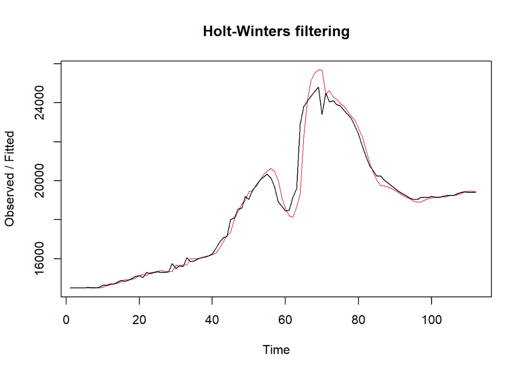

```r
#Lamda=0.6 dan gamma=0.3
des.2<- HoltWinters(train.ts, gamma = FALSE, beta = 0.3, alpha = 0.6)
plot(des.2)
```

```r
#ramalan
ramalandes2<- forecast(des.2, h=27)
ramalandes2
```

```
##     Point Forecast     Lo 80    Hi 80     Lo 95    Hi 95
## 113       19428.32 18752.976 20103.66 18395.472 20461.16
## 114       19439.07 18582.582 20295.55 18129.187 20748.95
## 115       19449.82 18375.624 20524.01 17806.980 21092.66
## 116       19460.57 18138.971 20782.17 17439.360 21481.78
## 117       19471.32 17877.174 21065.47 17033.284 21909.36
## 118       19482.07 17593.290 21370.85 16593.430 22370.71
## 119       19492.82 17289.473 21696.17 16123.091 22862.55
## 120       19503.57 16967.313 22039.83 15624.698 23382.45
## 121       19514.32 16628.037 22400.61 15100.129 23928.52
## 122       19525.07 16272.626 22777.52 14550.885 24499.26
## 123       19535.83 15901.893 23169.76 13978.206 25093.44
## 124       19546.58 15516.521 23576.63 13383.139 25710.01
## 125       19557.33 15117.101 23997.55 12766.587 26348.07
## 126       19568.08 14704.148 24432.01 12129.339 27006.82
## 127       19578.83 14278.119 24879.54 11472.093 27685.57
## 128       19589.58 13839.425 25339.73 10795.477 28383.68
## 129       19600.33 13388.436 25812.23 10100.057 29100.61
## 130       19611.08 12925.488 26296.68  9386.348 29835.82
## 131       19621.83 12450.891 26792.77  8654.824 30588.84
## 132       19632.58 11964.931 27300.24  7905.920 31359.25
## 133       19643.33 11467.870 27818.80  7140.040 32146.63
## 134       19654.09 10959.954 28348.22  6357.558 32950.61
## 135       19664.84 10441.412 28888.26  5558.826 33770.85
## 136       19675.59  9912.459 29438.72  4744.171 34607.00
## 137       19686.34  9373.296 29999.38  3913.901 35458.78
## 138       19697.09  8824.114 30570.06  3068.309 36325.87
## 139       19707.84  8265.092 31150.59  2207.667 37208.01
```

Selanjutnya jika ingin membandingkan plot data latih dan data uji adalah sebagai berikut.

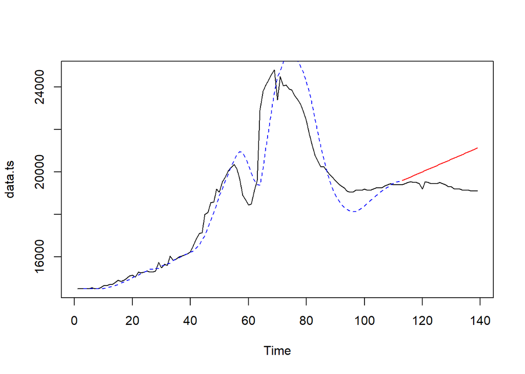

```r
#Visually evaluate the prediction
plot(data.ts)
lines(des.1$fitted[,1], lty=2, col="blue")
lines(ramalandes1$mean, col="red")
```

Untuk mendapatkan nilai parameter optimum dari DES, argumen `alpha` dan `beta` dapat dibuat `NULL` seperti berikut.

```r
#Lamda dan gamma optimum
des.opt<- HoltWinters(train.ts, gamma = FALSE)
des.opt
```

```
## Holt-Winters exponential smoothing with trend and without seasonal component.
##
## Call:
## HoltWinters(x = train.ts, gamma = FALSE)
##
## Smoothing parameters:
##  alpha: 1
##  beta : 0.2435476
##  gamma: FALSE
##
## Coefficients:
##           [,1]
## a 19400.000000
## b     9.773732
```

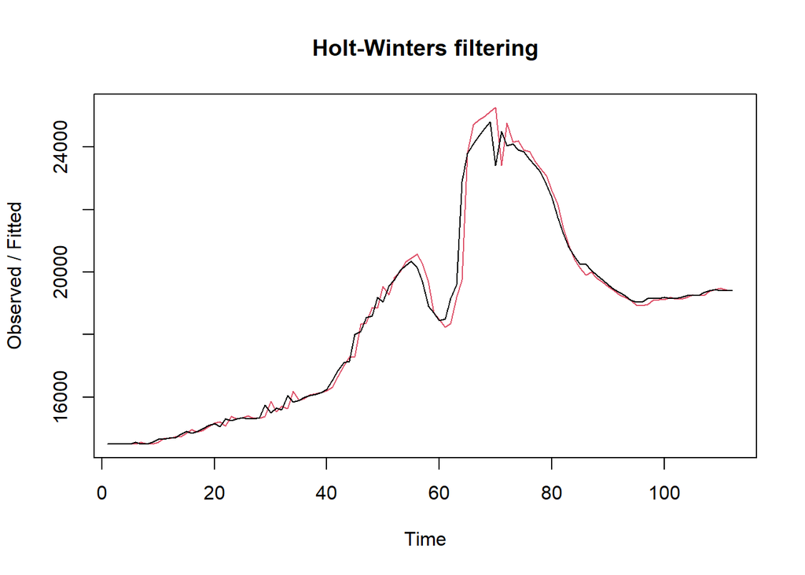

```r
plot(des.opt)
```

```r
#ramalan
ramalandesopt<- forecast(des.opt, h=27)
ramalandesopt
```

```
##     Point Forecast     Lo 80    Hi 80      Lo 95    Hi 95
## 113       19409.77 18850.311 19969.24 18554.1500 20265.40
## 114       19419.55 18526.787 20312.31 18054.1879 20784.91
## 115       19429.32 18208.993 20649.65 17562.9898 21295.65
## 116       19439.09 17881.318 20996.87 17056.6803 21821.51
## 117       19448.87 17539.273 21358.46 16528.3935 22369.34
## 118       19458.64 17181.364 21735.92 15975.8464 22941.44
## 119       19468.42 16807.192 22129.64 15398.4250 23538.41
## 120       19478.19 16416.810 22539.57 14796.2135 24160.17
## 121       19487.96 16010.476 22965.45 14169.6047 24806.32
## 122       19497.74 15588.534 23406.94 13519.1261 25476.35
## 123       19507.51 15151.362 23863.66 12845.3565 26169.67
## 124       19517.28 14699.347 24335.22 12148.8843 26885.69
## 125       19527.06 14232.864 24821.25 11430.2871 27623.83
## 126       19536.83 13752.279 25321.39 10690.1213 28383.54
## 127       19546.61 13257.937 25835.27  9928.9171 29164.29
## 128       19556.38 12750.168 26362.59  9147.1776 29965.58
## 129       19566.15 12229.283 26903.02  8345.3785 30786.93
## 130       19575.93 11695.575 27456.28  7523.9691 31627.89
## 131       19585.70 11149.323 28022.08  6683.3736 32488.03
## 132       19595.47 10590.787 28600.16  5823.9931 33366.96
## 133       19605.25 10020.216 29190.28  4946.2065 34264.29
## 134       19615.02  9437.845 29792.20  4050.3728 35179.67
## 135       19624.80  8843.896 30405.70  3136.8319 36112.76
## 136       19634.57  8238.579 31030.56  2205.9066 37063.23
## 137       19644.34  7622.096 31666.59  1257.9032 38030.78
## 138       19654.12  6994.637 32313.60   293.1136 39015.12
## 139       19663.89  6356.384 32971.40  -688.1845 40015.97
```

Selanjutnya akan dilakukan perhitungan akurasi pada data latih maupun data uji dengan ukuran akurasi SSE, MSE dan MAPE.

#### Akurasi Data Latih

```r
#Akurasi Data Training
ssedes.train1<-des.1$SSE
msedes.train1<-ssedes.train1/length(train.ts)
sisaandes1<-ramalandes1$residuals
head(sisaandes1)
```

```
## Time Series:
## Start = 1
## End = 6
## Frequency = 1
## [1] NA NA  0  0  0 50
```

```r
mapedes.train1 <- sum(abs(sisaandes1[3:length(train.ts)]/train.ts[3:length(train.ts)])
                      *100)/length(train.ts)

akurasides.1 <- matrix(c(ssedes.train1,msedes.train1,mapedes.train1))
row.names(akurasides.1)<- c("SSE", "MSE", "MAPE")
colnames(akurasides.1) <- c("Akurasi lamda=0.2 dan gamma=0.2")
akurasides.1
```

```
##      Akurasi lamda=0.2 dan gamma=0.2
## SSE                     1.139709e+08
## MSE                     1.017598e+06
## MAPE                    3.103897e+00
```

```r
ssedes.train2<-des.2$SSE
msedes.train2<-ssedes.train2/length(train.ts)
sisaandes2<-ramalandes2$residuals
head(sisaandes2)
```

```
## Time Series:
## Start = 1
## End = 6
## Frequency = 1
## [1] NA NA  0  0  0 50
```

```r
mapedes.train2 <- sum(abs(sisaandes2[3:length(train.ts)]/train.ts[3:length(train.ts)])
                      *100)/length(train.ts)

akurasides.2 <- matrix(c(ssedes.train2,msedes.train2,mapedes.train2))
row.names(akurasides.2)<- c("SSE", "MSE", "MAPE")
colnames(akurasides.2) <- c("Akurasi lamda=0.6 dan gamma=0.3")
akurasides.2
```

```
##      Akurasi lamda=0.6 dan gamma=0.3
## SSE                     3.026912e+07
## MSE                     2.702600e+05
## MAPE                    1.193476e+00
```

Hasil akurasi dari data latih didapatkan skenario 2 dengan lamda=0.6 dan gamma=0.3 memiliki hasil yang lebih baik karena nilai MAPE nya lebih kecil yaitu sebesar 1.19. Namun untuk kedua skenario dapat dikategorikan peramalan sangat baik berdasarkan nilai MAPE-nya karena kurang dari 10%.

#### Akurasi Data Uji

```r
#Akurasi Data Testing
selisihdes1<-ramalandes1$mean-testing$Harga
selisihdes1
```

```
## Time Series:
## Start = 113
## End = 139
## Frequency = 1
##  [1]  195.6693  204.7814  213.8934  223.0055  332.1176  391.2296  500.3417
##  [8]  809.4537  518.5658  627.6779  736.7899  795.9020  855.0140  864.1261
## [15]  973.2382 1082.3502 1241.4623 1300.5743 1459.6864 1518.7985 1577.9105
## [22] 1687.0226 1746.1346 1805.2467 1914.3588 1973.4708 2032.5829
```

```r
SSEtestingdes1<-sum(selisihdes1^2)
MSEtestingdes1<-SSEtestingdes1/length(testing$Harga)
MAPEtestingdes1<-sum(abs(selisihdes1/testing$Harga)*100)/length(testing$Harga)

selisihdes2<-ramalandes2$mean-testing$Harga
selisihdes2
```

```
## Time Series:
## Start = 113
## End = 139
## Frequency = 1
##  [1]  28.31583 -10.93322 -50.18227 -89.43133 -28.68038 -17.92943  42.82152
##  [8] 303.57246 -35.67659  25.07436  85.82531  96.57625 107.32720  68.07815
## [15] 128.82910 189.58005 300.33099 311.08194 421.83289 432.58384 443.33478
## [22] 504.08573 514.83668 525.58763 586.33857 597.08952 607.84047
```

```r
SSEtestingdes2<-sum(selisihdes2^2)
MSEtestingdes2<-SSEtestingdes2/length(testing$Harga)
MAPEtestingdes2<-sum(abs(selisihdes2/testing$Harga)*100)/length(testing$Harga)

selisihdesopt<-ramalandesopt$mean-testing$Harga
selisihdesopt
```

```
## Time Series:
## Start = 113
## End = 139
## Frequency = 1
##  [1]    9.773732  -30.452536  -70.678804 -110.905071  -51.131339  -41.357607
##  [7]   18.416125  278.189857  -62.036411   -2.262679   57.511054   67.284786
## [13]   77.058518   36.832250   96.605982  156.379714  266.153446  275.927179
## [19]  385.700911  395.474643  405.248375  465.022107  474.795839  484.569571
## [25]  544.343304  554.117036  563.890768
```

```r
SSEtestingdesopt<-sum(selisihdesopt^2)
MSEtestingdesopt<-SSEtestingdesopt/length(testing$Harga)
MAPEtestingdesopt<-sum(abs(selisihdesopt/testing$Harga)*100)/length(testing$Harga)

akurasitestingdes <-
  matrix(c(SSEtestingdes1,MSEtestingdes1,MAPEtestingdes1,SSEtestingdes2,MSEtestingdes2,
           MAPEtestingdes2,SSEtestingdesopt,MSEtestingdesopt,MAPEtestingdesopt),
         nrow=3,ncol=3)
row.names(akurasitestingdes)<- c("SSE", "MSE", "MAPE")
colnames(akurasitestingdes) <- c("des ske1","des ske2","des opt")
akurasitestingdes
```

```
##          des ske1     des ske2      des opt
## SSE  3.778492e+07 2.807626e+06 2.367320e+06
## MSE  1.399442e+06 1.039861e+05 8.767851e+04
## MAPE 5.304171e+00 1.263607e+00 1.153424e+00
```

Nilai MAPE yang dihasilkan pada data uji juga dikategorikan sangat baik karena nilai MAPE kurang dari 10%

##Kesimpulan Kedua Metode pemulusan yang digunakan (DMA dan DES)menghasilkan peramalan yang sangat baik karena nilai MAPE yang dihasilkan sangat kecil.